# MIZER

Anxo Paz

04/03/2026

## Hake models

Hake is the species for which we have the most information, and therefore we will work with it first.

### Load biological parameters and catch data

```r
# Biological parameters ----------------------------

load('input/Bio_Pars.RData')
load('input/Catch.RData')
load('input/Hake_SS_Data.RData')

## Species params

sp <- bio_pars@species_params |>
  select(species, w_mat, age_mat, w_max, a, b, pred_kernel_type, beta, sigma)


# Biomass ------------

quantity <- 'biomass' # 'SSB'
ss_biomass <- assessment[,quantity][assessment$Year %in% aver_y]*1e6  # SS biomass (tonnes to grams)
obs_q <- sum(ss_biomass)/length(aver_y)
b_min <- lwf(4,a,b)
sp$biomass_observed <- obs_q
sp$biomass_cutoff <- b_min

l_max <- 1.001 * max(corLFD$length + 1, na.rm = TRUE)
sp$w_max = lwf(l_max, sp$a, sp$b)

sp$d <- -0.1217


## Allometric params

hake_model <- newAllometricParams(sp)
```

### One fleet (from commercial landings)

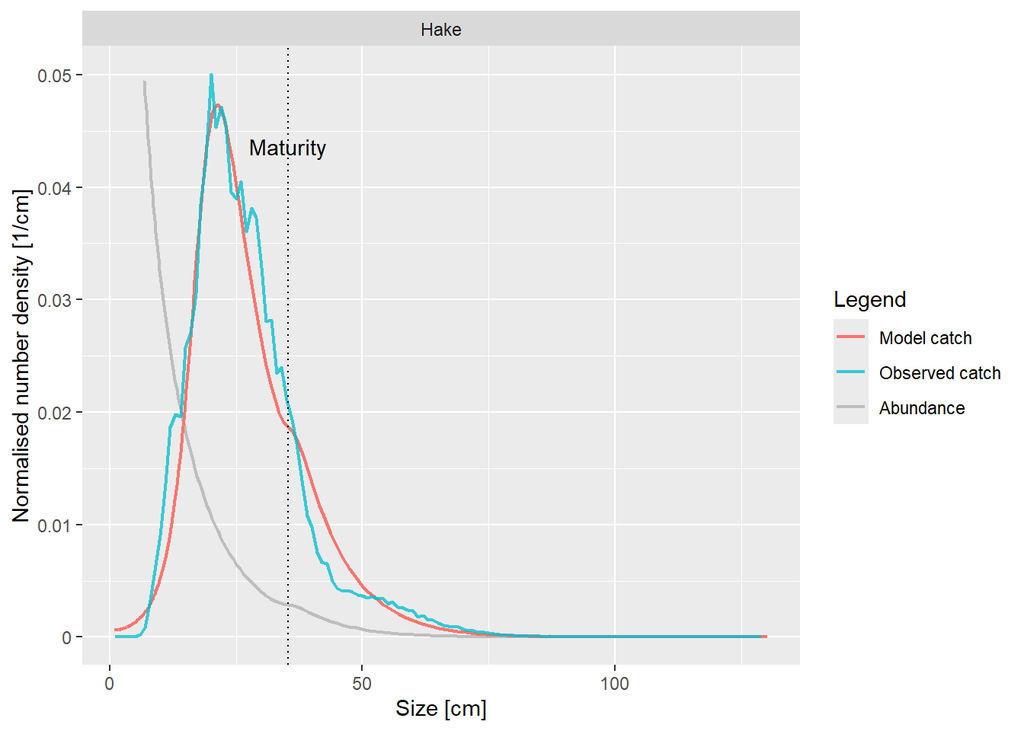

```r
gp <- data.frame(
  gear = "Total", species = "Hake", catchability = 1,
  sel_func = "sigmoid_length",
  l50 = 30,
  l25 = 28,
  yield_observed = sum(corLFDs$catch)
)

gear_params(hake_model) <- gp
initial_effort(hake_model) <- 1

yield <- getYield(hake_model)
gp$catchability <- gp$yield_observed / yield
gear_params(hake_model) <- gp

catch_onefleet <- corLFD |> group_by(length) |> summarise(catch = sum(number)) |>
  mutate( dl = 1, species = 'Hake', gear = "Total")

hake_model_newfun <- mizerEcopath::matchCatch(hake_model, catch = catch_onefleet)
plotYieldVsSize(hake_model_newfun, x_var = "Length", catch = catch_onefleet)
```

### Multiple fleets (from landings)

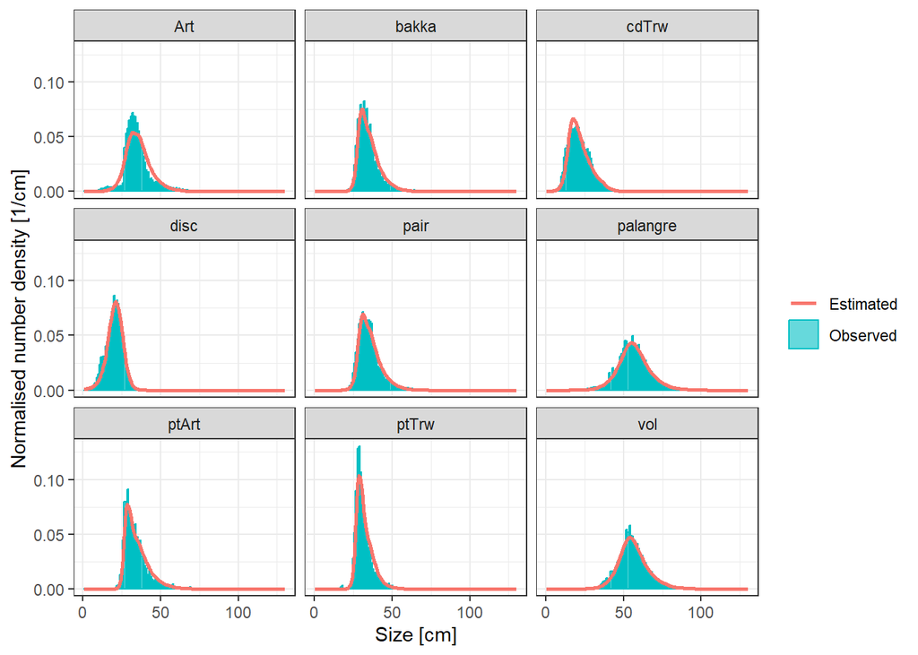

```r
catch_allfleets <- corLFD |>
  mutate( catch = number, gear = fleet, dl = 1, species = 'Hake') |>
  select( length, catch, dl, species, gear)

gear_names <- unique( catch_allfleets$gear)

gp <- data.frame(
  gear = gear_names,
  species = "Hake",
  sel_func = ifelse( gear_names %in% c('palangre','vol'), 'sigmoid_length', 'double_sigmoid_length'),
  l50 =       c( 28.6, 30.7, 29.8, 14.8, 27.5, 30.3, 51.2, 54.9, 16.1),
  l25 =       c( 23.8, 28.5, 27.4, 13.0, 26.6, 28.1, 47.5, 51.3, 13.5),
  l50_right = c( 38.3, 33.6, 42.0, 20.6, 33.1, NA,   58.0, 54.4, NA  ),
  l25_right = c( 43.3, 45.0, 47.8, 27.0, 38.9, NA,   67.9, 60.8, NA  ),
  yield_observed = corLFDs$catch,
  catchability = corLFDs$catch/sum(corLFDs$catch))

gear_params(hake_model) <- gp

initial_effort(hake_model) <- 1

hake_model_fleets <- mizerEcopath::matchCatch(hake_model, catch = catch_allfleets)

plotYieldVsSizeByGear(hake_model_fleets, catch = catch_allfleets)
```

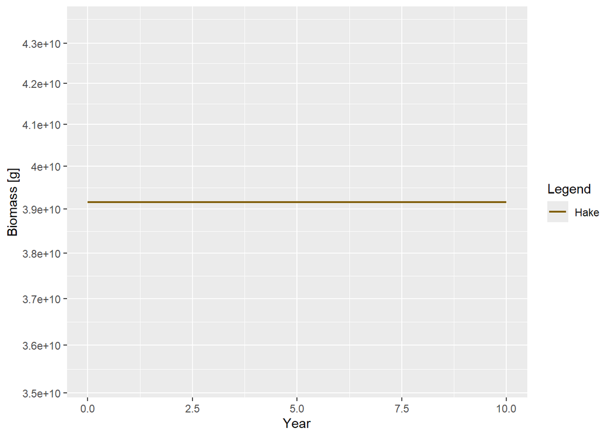

```r
plotBiomass( project(hake_model_fleets, t_max=10))
```

### Only with survey’s data

We wanted to test a model that only considered surveys as a source of information, since for the rest of the species we will only consider one survey to calibrate it.

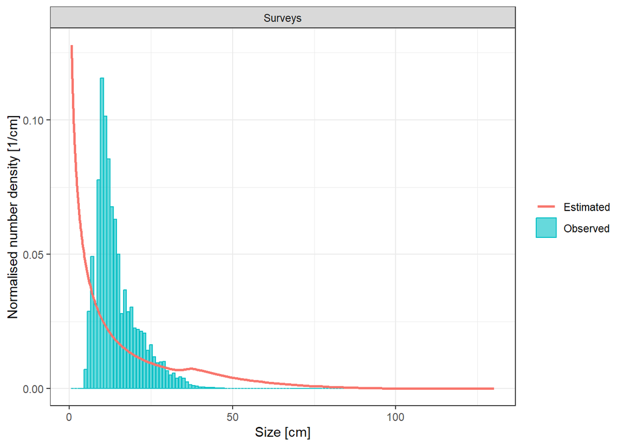

```r
surveys_sum <- LFD_sum_surv$aver_y
surveys_data <- LFD_list_surv$aver_y

### All in one survey

onesurvey <- surveys_data |> group_by(length) |> summarise(catch = sum(number)) |>
  mutate( dl = 1, species = 'Hake', gear = "Surveys")

max_length <- onesurvey %>% filter(catch == max(catch)) %>% ungroup()

surv_names <- unique( onesurvey$gear)

gp <- data.frame(
  gear = surv_names,
  species = "Hake",
  sel_func = rep( 'sigmoid_length', length(surv_names)),
  l50 = max_length$length*0.8,
  l25 = max_length$length*0.7,
  yield_observed = sum(surveys_sum$catch),
  catchability = 1)

gear_params(hake_model) <- gp

initial_effort(hake_model) <- 1

hake_model_onesurvey <- mizerEcopath::matchCatch(hake_model, catch = onesurvey)
plotYieldVsSizeByGear(hake_model_onesurvey, catch = onesurvey)
```

```r
### Three separated surveys

surveys <- surveys_data |>
  mutate( catch = number, gear = fleet, dl = 1, species = 'Hake') |>
  select( length, catch, dl, species, gear)

max_length <- surveys %>% group_by(gear) %>%
  filter(catch == max(catch)) %>% ungroup()

surv_names <- unique( surveys$gear)

gp <- data.frame(
  gear = surv_names,
  species = "Hake",
  sel_func = rep( 'sigmoid_length', length(surv_names)),
  l50 = max_length$length*0.8,
  l25 = max_length$length*0.7,
  yield_observed = surveys_sum$catch,
  catchability = surveys_sum$catch/sum(surveys_sum$catch))

gear_params(hake_model) <- gp

initial_effort(hake_model) <- 1

hake_model_surveys <- mizerEcopath::matchCatch(hake_model, catch = surveys)
```

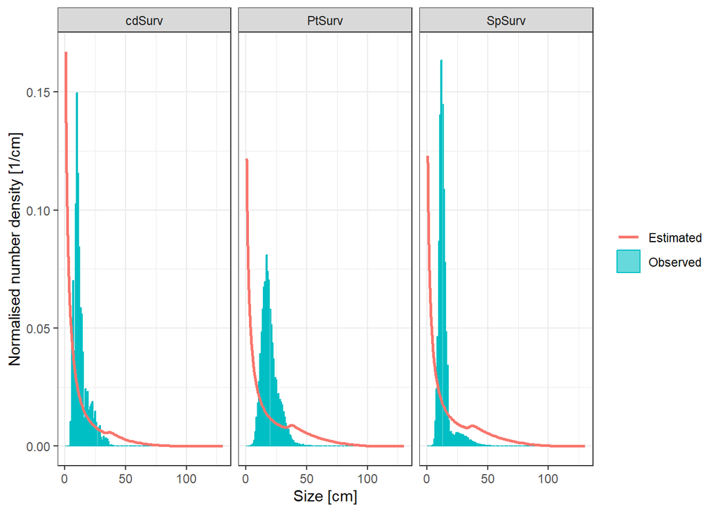

```r
plotYieldVsSizeByGear(hake_model_surveys, catch = surveys)
```

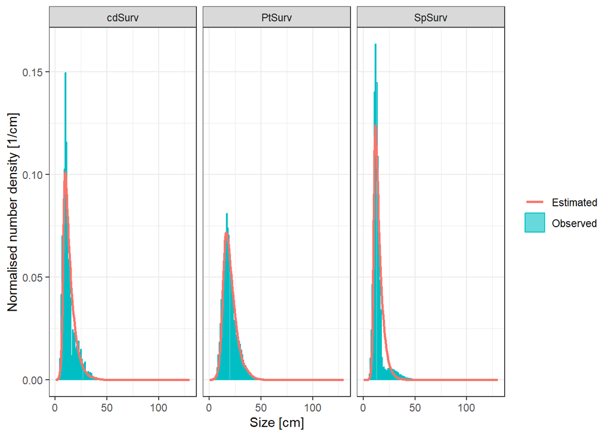

```r
gp <- data.frame(
  gear = surv_names,
  species = "Hake",
  sel_func = rep( 'double_sigmoid_length', length(surv_names)),
  l50 = max_length$length*0.8,
  l25 = max_length$length*0.7,
  l50_right = max_length$length*1.2,
  l25_right = max_length$length*1.3,
  yield_observed = surveys_sum$catch,
  catchability = surveys_sum$catch/sum(surveys_sum$catch))

gear_params(hake_model) <- gp

hake_model_surveys <- mizerEcopath::matchCatch(hake_model, catch = surveys)
plotYieldVsSizeByGear(hake_model_surveys, catch = surveys)
```

It seems the in these cases the sigmoid selectivity is not appropriate, because setting this tells the model that there is no fish in bigger sizes, but setting it double sigmoid also gives few information to the model.

### All catch data

At last, we also try to run a model with both data sources (commercial landings and surveys)

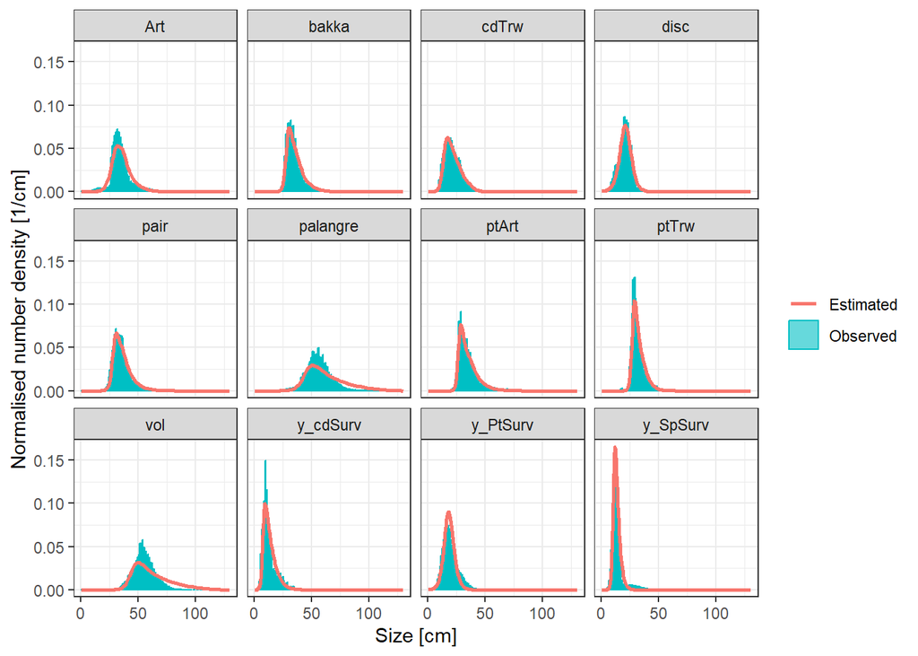

```r
surveys <- surveys_data |>
  mutate( catch = number, gear = fleet, dl = 1, species = 'Hake') |>
  select( length, catch, dl, species, gear) |>
  mutate( gear = paste0('y_', gear))      # to maintain alphabetical order

all_c <- rbind( catch_allfleets, surveys); all_c

gear_names <- c( unique( catch_allfleets$gear), unique( surveys$gear))

gp <- data.frame(
  gear = gear_names,
  species = "Hake",
  sel_func = ifelse( gear_names %in% c('palangre','vol'), 'sigmoid_length', 'double_sigmoid_length'),
  l50 =       c( 30, 30, 30, 15, 30, 50, 30, 30, 50, max_length$length*0.7),
  l25 =       c( 25, 25, 25, 10, 25, 45, 25, 25, 45, max_length$length*0.6),
  l50_right = c( 35, 35, 35, 20, 35, NA, 35, 35, NA, max_length$length*1.1),
  l25_right = c( 40, 40, 40, 25, 40, NA, 40, 40, NA , max_length$length*1.2),
  yield_observed = c(corLFDs$catch,surveys_sum$catch),
  catchability = c(corLFDs$catch,surveys_sum$catch)/sum(corLFDs$catch,surveys_sum$catch))

gear_params(hake_model) <- gp

initial_effort(hake_model) <- 1

hake_m <- mizerEcopath::matchCatch(hake_model, catch = all_c)
plotYieldVsSizeByGear(hake_m, catch = all_c)
```

### Selected model

The final decision, considering the results, was to continue with the model with the commercial landigs data.

With this model, where reproduction is not initially active, we wanted to see what would happen considering different reproduction levels, to verify that the “erepro” values remained within feasible ranges.

```r
hake_model <- hake_model_fleets
hake_catch <- catch_allfleets

hake_model_0 <- setBevertonHolt( hake_model, reproduction_level = 0)
hake_model_0@species_params$erepro
```

```
## [1] 0.0004325668
```

```r
hake_model_99 <- setBevertonHolt( hake_model, reproduction_level = 0.99)
hake_model_99@species_params$erepro
```

```
## [1] 0.04325668
```

```r
hake_model_erepro05 <- setBevertonHolt( hake_model, erepro = 0.5)
getReproductionLevel( hake_model_erepro05)
```

```
##      Hake
## 0.9991349
```

## Other species

We have some information for other species as well, but not as complete as in the hake case.

```r
load('input/Catch_spp.RData')
load('input/other_spp_rmd.RData')

# Parameters

pars <- other_spp$short_fb
tibble( pars)
```

```
## # A tibble: 7 × 10
##   red      esp                common       a     b l_inf   kvb   al0 l_mat l_max
##   <chr>    <chr>              <chr>    <dbl> <dbl> <dbl> <dbl> <dbl> <dbl> <dbl>
## 1 Eng_encr Engraulis encrasi… Ancho… 0.00556  3.09  18.2  0.79 -1     13.7  18.2
## 2 Lep_bosc Lepidorhombus bos… Four-… 0.0042   3.18  37.1  0.21 -0.47  18    37.1
## 3 Lep_whif Lepidorhombus whi… Megrim 0.005    3.10  53    0.17 -0.59  25.8  53
## 4 Mic_pout Micromesistius po… Blue … 0.0038   3.13  34.7  0.36 -1.07  18.2  34.7
## 5 Sar_pilc Sardina pilchardus Pilch… 0.0108   2.91  20.7  0.69 -0.64  14.5  20.7
## 6 Sco_scom Scomber scombrus   Macke… 0.0053   3.08  37.4  0.47 -0.97  28.7  37.4
## 7 Tra_trac Trachurus trachur… Horse… 0.0129   2.85  38    0.25 -0.98  21    38
```

```r
spps <- pars$red


## SSB --------------

ssb_long <- bind_rows(other_spp_ices, .id = "species") |> filter( Year >= 1992, Year <= 2023)
ssb_spp <- ssb_long |> pivot_wider( names_from = species, values_from = SSB) |> arrange(Year); ssb_spp
```

```
## # A tibble: 32 × 8
##     Year Eng_encr Sar_pilc Tra_trac Mic_pout Sco_scom Lep_bosc Lep_whif
##    <int>    <dbl>    <dbl>    <dbl>    <dbl>    <dbl>    <dbl>    <dbl>
##  1  1992    69536   856425  538901.   98295.      NA      4550     1301
##  2  1993    79176   969138  564075.  101461.      NA      3900     1169
##  3  1994    52870   816411  600192   101139.      NA      3956     1113
##  4  1995    46739   676554  568653.   92229.      NA      3628      787
##  5  1996    52667   541841  598686.   88338.      NA      2764      898
##  6  1997    54543   478487  621637.   98868.      NA      2509      987
##  7  1998    97481   382947  589403.  147450.  127568.     3622     1155
##  8  1999    78510   366206  619352   178122.  127063.     3427      870
##  9  2000    94427   312464  577640   169759.  117683.     2789      663
## 10  2001   107669   473643  537614.  183202.  109277.     2427      541
## # ℹ 22 more rows
```

```r
## LFD ------------------

LFD_data <- lapply(LFD_spp_tp, function(df) { split(df, df$spp)})
LFD_total <- lapply(LFD_spp_tp, function(df) { split(df, df$spp) |>
    lapply(function(x) sum(x$value, na.rm = TRUE))})

LFD_data$aver_y |> bind_rows() |> pivot_wider( names_from = spp, values_from = value) |> arrange(length)
```

```
## # A tibble: 60 × 8
##    length Eng_encr Lep_bosc Lep_whif Mic_pout Sar_pilc Sco_scom  Tra_trac
##     <dbl>    <dbl>    <dbl>    <dbl>    <dbl>    <dbl>    <dbl>     <dbl>
##  1      1  0        0        0          0      0              0  0
##  2      2  0        0.00280  0          0      0              0  0.000549
##  3      3  0        0.00192  0          0      0              0  0.0142
##  4      4  0        0.0354   0.00178    0      0              0  0.0942
##  5      5  0.00234  0.225    0.00330    0      0              0  0.239
##  6      6  0.116    0.625    0.00284    0      0              0  0.814
##  7      7  0.516    0.673    0.0201     0      0              0  3.72
##  8      8  1.69     0.342    0.0751     0      0              0  7.78
##  9      9  3.51     0.328    0.121      0      0              0 21.8
## 10     10  1.90     0.857    0.112      0.315  0.00216        0 70.0
## # ℹ 50 more rows
```

The major problem with this catch data is that it comes from a survey (“Demersal”) that is highly selective for certain size ranges. Furthermore, it is not specific to any particular species, so this specific size range means that for some species, such as small pelagic fish, the sizes will correspond to large individuals, while for demersal fish, which reach larger sizes, something similar to what occurred with hake will happen. In other words, how the fleet’s selectivity is handled can lead to different interpretations by the model (or it may assume that there are no large fish because it cannot find them, or that there is a significant lack of information on the largest sizes).

It should also be noted that in some cases the SSB obtained from the assessment models of the different species did not correspond to the study area. For example, the hake biomass corresponds to that estimated for ICES areas 8c9a, as does the SSB of some other species, but not all, such as blue whiting or mackerel. Failing to consider these differences led to models clearly dominated by these species, even though in none of them are they top predators at all (this is something we will see later, but which was addressed in a limited way).

HERE THERE IS CLEARLY GREAT ROOM FOR IMPROVEMENT IN THE MODEL

```r
lfd <- LFD_data$aver_y
lfd_total <- LFD_total$aver_y

bio <- ssb_spp |> filter(Year %in% years$aver_y) |>
  summarise(across(-Year, ~ mean(.x, na.rm = TRUE))) |>
  pivot_longer(cols = everything(), names_to = "species", values_to = "SSB")
```

```r
# trac_tra <- tibble(tra_tra_9a)|> select(Year, SSB)|> mutate(SSB=SSB*1.6)
# micr_pou <- tibble(mic_pou_191214)|> select(Year, SSB)|> mutate(SSB=SSB*0.04)
# scom_sco <- tibble(sco_sco)|> select(Year, SSB)|> mutate(SSB=SSB*0.04)
```

At this point, it’s worth noting that adjusting each species separately led to erepro values greater than 1, which doesn’t make sense. This is because, when allocating available energy for reproduction and growth, the portion dedicated to reproduction started earlier than expected due to the fixed value for $m$ in the equation used to obtain $\psi$. However, we allowed this m to vary during the optimization process.

```
##                     catchability              sel_func     l50      l25
## Anchovy, Demersales 0.0002033592 double_sigmoid_length 8.35897 7.927894
##                     l50_right l25_right yield_observed
## Anchovy, Demersales  8.359015  19.75723       18439371
##
##           m     erepro   mu_mat
## 1 0.7125172 0.02165021 2.608968
## [1] "erepro for a reproduction_level=0.5: 0.0433"
```

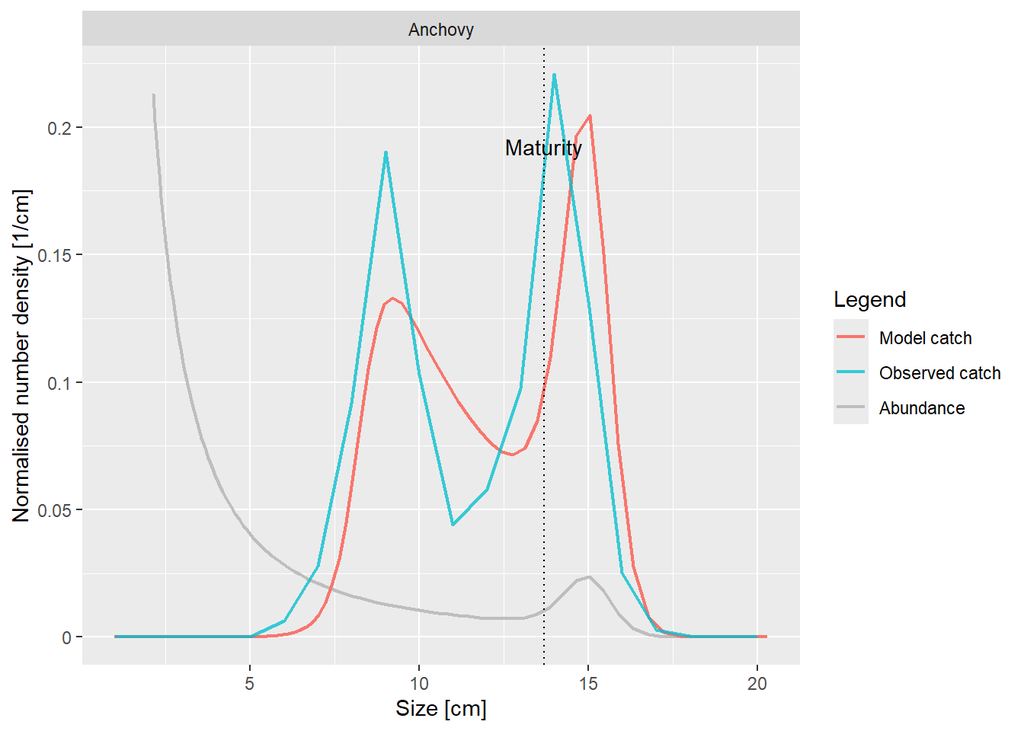

```
##                              catchability              sel_func      l50
## Four-spot megrim, Demersales    0.1509724 double_sigmoid_length 12.65862
##                                   l25 l50_right l25_right yield_observed
## Four-spot megrim, Demersales 10.92824  24.94018  27.49983       45560959
##
##          m       erepro    mu_mat
## 1 1.851308 4.542355e-05 0.3361917
## [1] "erepro for a reproduction_level=0.5: 1e-04"
```

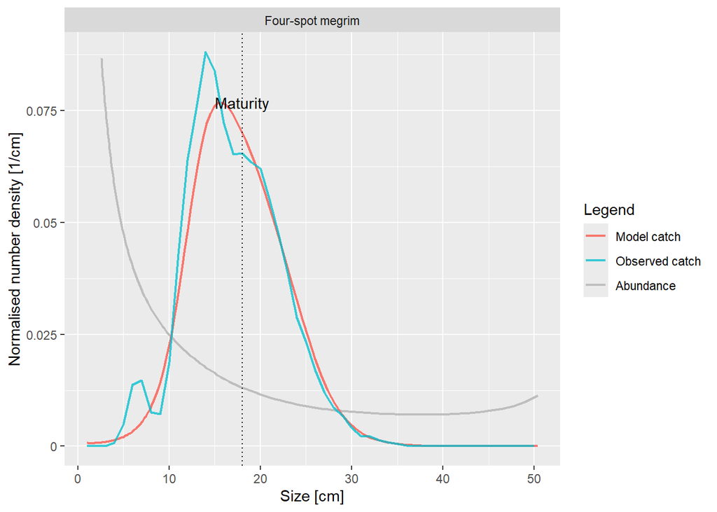

```
##                    catchability              sel_func      l50      l25
## Megrim, Demersales    0.2889271 double_sigmoid_length 16.36767 14.78556
##                    l50_right l25_right yield_observed
## Megrim, Demersales  28.52796  32.51873       26287284
##
##   m       erepro    mu_mat
## 1 3 0.0001697363 0.3159254
## [1] "erepro for a reproduction_level=0.5: 3e-04"
```

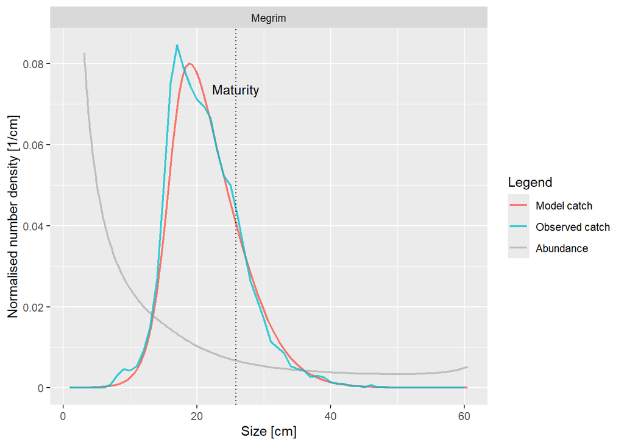

```
##                          catchability              sel_func      l50      l25
## Blue whiting, Demersales   0.08015918 double_sigmoid_length 14.85838 14.26482
##                          l50_right l25_right yield_observed
## Blue whiting, Demersales  14.86028  18.14972     1515921839
##
##          m    erepro mu_mat
## 1 1.131727 0.4539436      3
## [1] "erepro for a reproduction_level=0.5: 0.9079"
```

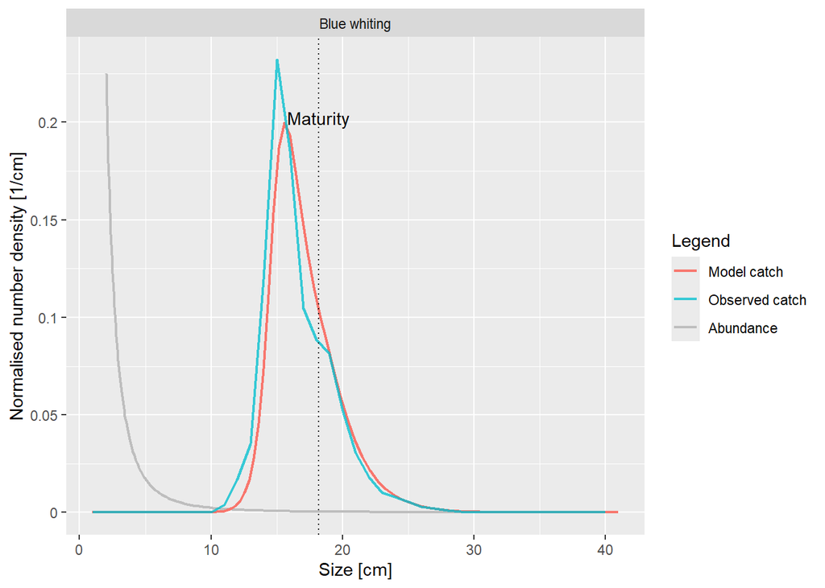

```
##                      catchability              sel_func      l50      l25
## Pilchard, Demersales 0.0005961451 double_sigmoid_length 21.05819 20.22335
##                      l50_right l25_right yield_observed
## Pilchard, Demersales  21.05919  21.73928        4241779
##
##          m    erepro mu_mat
## 1 2.666692 0.4249596   2.65
## [1] "erepro for a reproduction_level=0.5: 0.8499"
```

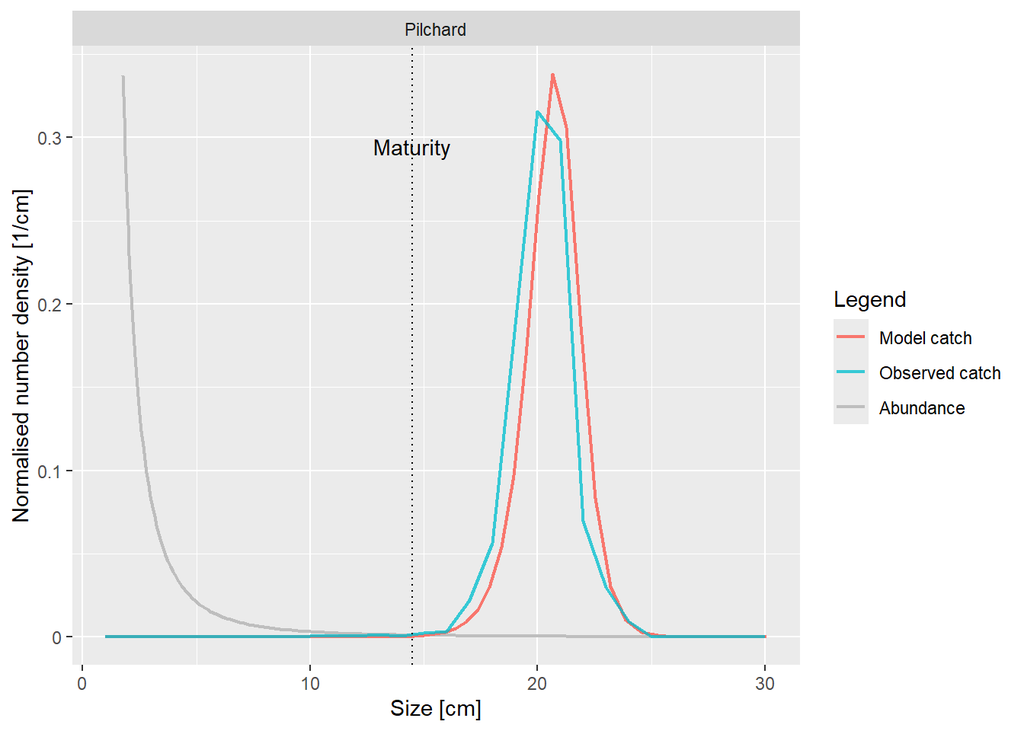

```
##                      catchability              sel_func      l50      l25
## Mackerel, Demersales  9.85441e-05 double_sigmoid_length 19.66815 19.25353
##                      l50_right l25_right yield_observed
## Mackerel, Demersales  19.66915   28.6278       13697575
##
##           m    erepro mu_mat
## 1 0.7365135 0.3384879    1.4
## [1] "erepro for a reproduction_level=0.5: 0.677"
```

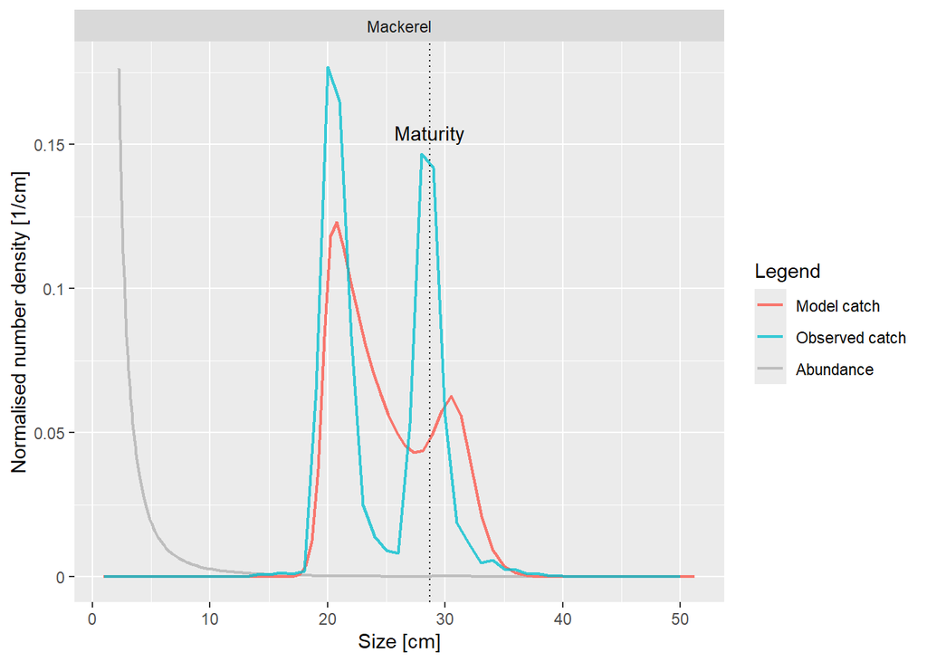

```
##                            catchability              sel_func     l50     l25
## Horse mackerel, Demersales   0.05103138 double_sigmoid_length 8.83923 8.31049
##                            l50_right l25_right yield_observed
## Horse mackerel, Demersales  8.839275   15.4458      278558410
##
##           m       erepro mu_mat
## 1 0.8122628 3.072517e-06    0.2
## [1] "erepro for a reproduction_level=0.5: 0"
```

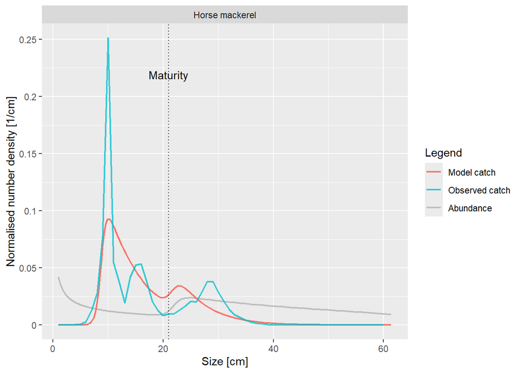

```r
spp_mods <- catch_mods <- plots_mods <- list()

for(i in spps){

  ipars <- pars |> filter( red == i)
  # issb <- bio |> filter( species == i) |> mutate( SSB = 10^6 * SSB, Bio = 10^6 * Bio)
  issb <- bio |> filter( species == i) |> mutate( SSB = 10^6 * SSB)
  ilfd <- lfd[[i]] |> mutate(catch = value * 10^6)
  icom <- ipars$common

  # ftype <- ifelse( icom %in% c( 'Mackerel', 'Four-spot megrim', 'Megrim'), 1, 2)
  ftype <- ifelse( icom %in% c( 'Mackerel', 'Four-spot megrim', 'Megrim'), 2, 2)

  l_max <- 1.001 * max(ilfd$length + 5, na.rm = TRUE)

  isp <- data.frame(
    species = icom,
    w_mat = lwf( ipars$l_mat, ipars$a, ipars$b),
    w_max = max( lwf( ipars$l_max, ipars$a, ipars$b), lwf( l_max, ipars$a, ipars$b)))

  isp$age_mat = laf( ipars$l_mat, ipars$l_inf, ipars$kvb, ipars$al0)
  isp$a = ipars$a
  isp$b = ipars$b

  isp$biomass_observed <- issb$SSB   # issb$Bio for Biomass
  isp$biomass_cutoff <- isp$w_mat    # lwf(4,ipars$a,ipars$b) if Biomass

  imodel <- newAllometricPars( isp, max_w = hake_model@species_params$w_max)

  if( ftype == 2){

    igp <- data.frame(
      gear = "Demersales",
      species = icom,
      catchability = 1,
      sel_func = "double_sigmoid_length",
      l50 = ipars$l_mat,
      l25 = ipars$l_mat*0.8,
      l50_right = ipars$l_mat*1.05,
      l25_right = ipars$l_mat*1.2,
      yield_observed = sum(ilfd$catch)
    )

  } else if( ftype == 1){

    igp <- data.frame(
      gear = "Demersales",
      species = icom,
      catchability = 1,
      sel_func = "sigmoid_length",
      l50 = ipars$l_mat,
      l25 = ipars$l_mat*0.8,
      yield_observed = sum(ilfd$catch)
    )
  }

  gear_params(imodel) <- igp
  initial_effort(imodel) <- 1

  yield <- as.numeric(getYield(imodel))
  igp$catchability <- igp$yield_observed / yield
  gear_params(imodel) <- igp

  icatch <- ilfd |> mutate( dl = 1, species = icom, gear = "Demersales") |>
    select( length, catch, dl, species, gear)

  mu_mat_lim <- 4
  erepro <- 1

  while( erepro > 0.5){

    mu_mat_lim <- mu_mat_lim - 0.05
    imodel <- suppressWarnings( mizerEcopath::matchCatch( imodel, catch = icatch, mu_mat_lim = mu_mat_lim, map = NULL))
    erepro <- imodel@species_params$erepro

  }

  spp_mods[[i]] <- imodel
  catch_mods[[i]] <- icatch
  plots_mods[[i]] <- plotYieldVsSize(imodel, x_var = "Length", catch = icatch)

  print( data.frame(spp_mods[[i]]@gear_params)[,(-c(1,2))])

  cat('\n')

  print( data.frame( m = spp_mods[[i]]@species_params$m,
                     erepro = spp_mods[[i]]@species_params$erepro,
                     mu_mat = spp_mods[[i]]@species_params$mu_mat))

  print(paste0('erepro for a reproduction_level=0.5: ',round( setBevertonHolt(imodel, reproduction_level = 0.5)@species_params$erepro,4)))
  cat('\n'); cat('\n')

  print(plotYieldVsSize( spp_mods[[i]], x_var = "Length", catch = catch_mods[[i]]))

}
```

```r
for(i in spps) print(data.frame(SSB_obs = spp_mods[[i]]@species_params$biomass_observed/10^6,
                                SSB_estwbio = getSSB(spp_mods[[i]])/10^6,
                                SSB_est = getBiomass(spp_mods[[i]], use_cutoff = T)/10^6))
```

```
##          SSB_obs SSB_estwbio  SSB_est
## Anchovy 169386.7      158400 169386.7
##                  SSB_obs SSB_estwbio SSB_est
## Four-spot megrim  9419.5    9420.995  9419.5
##        SSB_obs SSB_estwbio SSB_est
## Megrim  1616.8    1614.901  1616.8
##               SSB_obs SSB_estwbio  SSB_est
## Blue whiting 186772.5    184515.9 186772.5
##           SSB_obs SSB_estwbio  SSB_est
## Pilchard 297102.4    295795.2 297102.4
##           SSB_obs SSB_estwbio  SSB_est
## Mackerel 336012.7    308905.2 336012.7
##                 SSB_obs SSB_estwbio  SSB_est
## Horse mackerel 601865.9    601069.5 601865.9
```

```r
print( data.frame( species = 'Hake', m = hake_model@species_params$m,
                   erepro = hake_model@species_params$erepro,
                   mu_mat = hake_model@species_params$mu_mat))
```

```
##   species m       erepro   mu_mat
## 1    Hake 1 0.0004325668 1.152416
```

At this point, two things are worth highlighting. First, the adjustment using the previous function resulted in exaggerated external mortality, leading to very high $erepro$ values. We came up with the solution of setting an upper limit to prevent mortality from being so high. The problem is knowing how to limit it. Here we realized that when allocating available energy for reproduction and growth, the portion corresponding to reproduction started earlier than expected due to the value set for $m$ in the equation for obtaining $\psi$. However, we allowed this $m$ to vary in the optimization, so less was invested in reproduction in smaller sizes, which in turn reduced the need for such a high mortality limit. Taking these two aspects into account, the loop shows how erepro is calculated after an initial adjustment to bring it to a reasonable value (< 0.5), decreasing this new `mu_mat_lim` argument in the `mizerEcopath::matchCatch()` function and allowing $m$ to be estimated.

## Multispecies modeling

Now, with fishing mortality adjusted for each species separately, we can build our first multispecies model. Things to consider:

- The models must be in a steady state, which is a direct consequence of the previous adjustment.
- Each model must have zero interaction with both resources and other species. No interaction is necessary at this stage, as we are currently only modeling the balance between growth and mortality, and the only sources of mortality are fishing and external factors, which should be sufficient to explain the system’s behavior.

Furthermore, it is not yet necessary to define the desired reproduction level.

The function for linking species has been modified to transmit not only biological and fishing parameter information, but also available biomass and mortality associated with each model.

We are also checking that the full multispecies model is in steady state too (it should be because we didn’t modify anithing at this point, species are non interacting)

```r
allcatch <- c( list( Hake = hake_catch), catch_mods)
allmods <- c( Hake = hake_model, spp_mods)

catchdf <- bind_rows( allcatch)

msm <- mizerEcopath::bindParams( allmods)

msm@linecolour[1:8] <- NS_params@linecolour[1:8] # this should be solved at some point

sim <- project(msm, t_max = 10)
plotBiomass(sim)
```

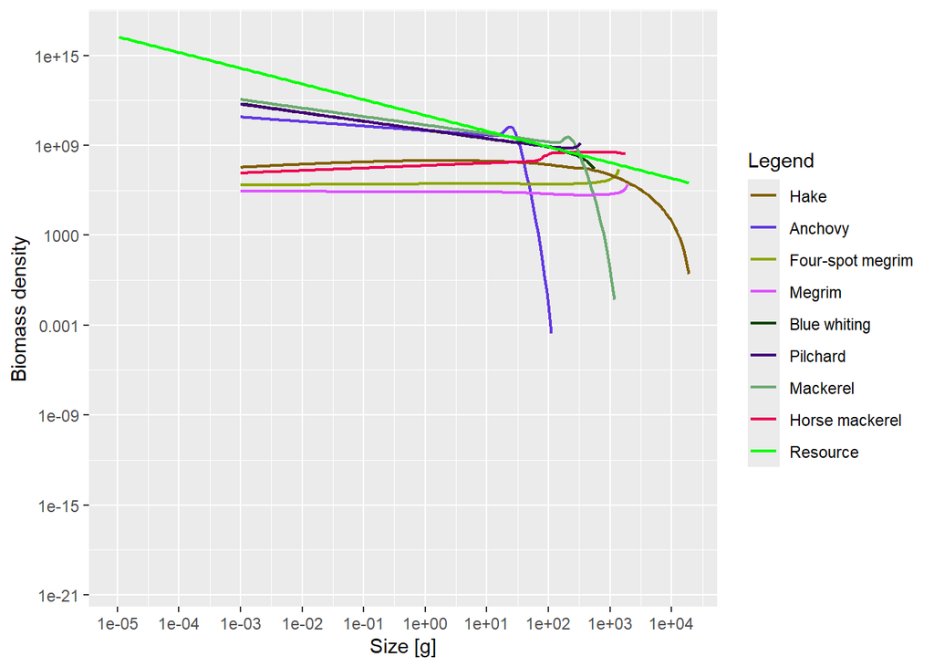

```r
plotSpectra(msm)
```

### Predation

To activate the interaction, thus triggering predation mortality, the parameters for the pred_kernel of the model for the North Celtic Sea were first selected for the species that matched, since we only had known information for the hake. For the other species, Anchovy and Sardine, these were obtained from Mariella’s data.

It’s worth mentioning in this section that we discovered that simply changing the parameters directly in the `species_params` object wasn’t enough (this can’t be done with the `species_params()` function at the moment because it leads to an incorrect interpretation of them), we also had to inform the model using the `setPredKernel()` function to take these changes into account.

```r
sp <- msm@species_params

celpars <- mizerEcopath::celtic_params@species_params

anc_sar_kerpars <-
  readRDS("data/anchovy_sardine_kernel_params.rds")

trcols <- c("pred_kernel_type", "kernel_exp", "kernel_l_l", "kernel_u_l", "kernel_l_r", "kernel_u_r")

for (col in trcols) {if (!col %in% names(sp)) { sp[[col]] <- NA}}

for (i in seq_len(nrow(sp))) {
  sp_name <- sp$species[i]
  if (sp_name %in% celpars$species) {
    row_cel <- celpars[celpars$species == sp_name, trcols]
    sp[i, trcols] <- row_cel
  }
}

sp[sp$species == "Four-spot megrim", trcols] <- sp[sp$species == "Megrim", trcols]

sp[which(sp$species=='Hake'), 'pred_kernel_type'] <- 'lognormal'     # comment for using celtic values

anc_sar_kerpars$pred_kernel_type <- anc_sar_kerpars$kernel_type
sp[c('Anchovy','Pilchard'),trcols] <- anc_sar_kerpars[,trcols]

msm@species_params <- sp
msm <- setPredKernel(msm)

sim <- project(msm, t_max = 10)
plotBiomass(sim)
```

### Feeding level

The next step, after turning on the predation kernel parameters, is determining the feeding level. For this process we are using the default parameters.

```r
msm <- setFeedingLevels(msm, f = 0.6, f_c = 0.2)

sim <- project(msm, t_max = 10)
plotBiomass(sim)
```

### Interaction

Now it’s time to turn on the interaction between all the species involved in the model. There are two options available at this moment, using an uniform interaction matrix, that set all the interactions equal to 1 (the default value where the predation is only determined by the predator/prey sizes relationship), or creating an ad-hoc matrix where you can establish different preferences for each predator and prey.

These functions allow us to extract predation mortality from external mortality, considering that one must be reduced relative to the other to avoid disrupting the system’s steady state. To do this, the encounter rate and associated mortality for each species are extracted before predation is triggered, and then the difference obtained in this process is subtracted.

For this specific case, the decision that we made is to define the top-predators (demersal fishes) and establish some differences in comparison with the pelagic fish (the biological reason behind this decision is that in the water column top-predators comes up to eat, but the pelagic ones do not show the opposite bahaviour).

```r
nsp <- nrow(species_params(msm))
sps <- msm@species_params$species
interaction_mat <- matrix( 0.2, nsp, nsp, dimnames = list(sps, sps))

for(i in sps){
  if(i %in% c('Megrim', 'Four-spot megrim')) interaction_mat[i,] <- 0.8
  if(i == 'Hake') interaction_mat[i,] <- 1
}

msm1 <- setUniformInteraction( msm); msm12 <- setNotUniformInteraction( msm) # the results of this two options should be the same

msm <- setNotUniformInteraction( msm, interaction_mat = interaction_mat)

interaction_matrix(msm); interaction_matrix(msm1); interaction_matrix(msm12)

plotDiet(msm); plotDiet(msm1); plotDiet(msm12)
```

```r
plotDeath(msm); plotDeath(msm1); plotDeath(msm12)
```

```r
plotBiomass( project(msm, t_max=10))
```

```r
plotBiomass( project(msm1, t_max=10))
```

```r
plotBiomass( project(msm12, t_max=10))
```

### Resource

The last step to obtain the model with the correct predation levels is to establish the interaction with the resource, which until now is null and which by default is constant, so that the smallest fish are able to feed on the resource, considering resource as those microorganisms (the cut-off is set at < 1 g in this case) available in the environment.

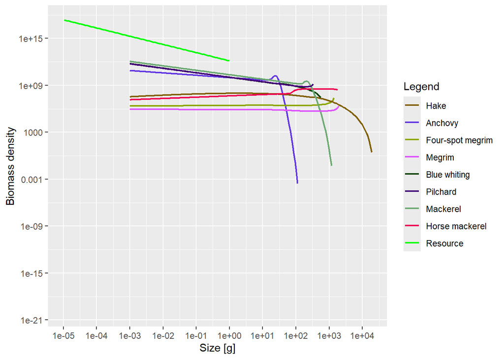

```r
msm <- alignResource(msm, w_pp_cutoff = 1)
msm <- setResourceInteraction(msm, "resource_semichemostat")

resource_level(msm)
plotSpectra(msm)
```

```r
sim <- project(msm, t_max = 10)
plotBiomass(sim)
```

### Reproduction level

The final step is to establish an appropriate reproduction level for the different species. In this case, a reproduction_level of 0.5 has been chosen, as it represents a plausible level that each species can sustain without having to expend excessive energy.

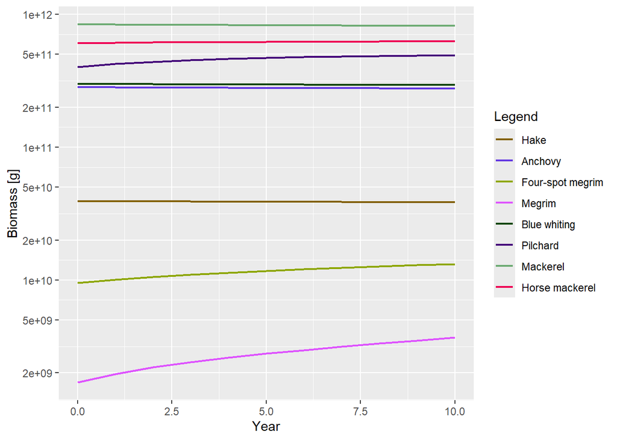

```r
msm <- setBevertonHolt(msm, reproduction_level = 0.5)

sim <- project(msm, t_max = 10)
plotBiomass(sim)
```

## Projections

Once the final model is obtained, it can be used to generate projections at different fishing effort levels. It’s important to note that the selectivity and catchability of each species have been estimated using a fishing effort of 1, making it easier to work with.

By multiplying the effort of one or more fleets simultaneously, differences can be observed across the entire ecosystem, reflecting the higher fishing mortality associated with each fleet. The same occurs when varying catchability, which, at the same effort level, allows us to work with each species separately within the same fleet (as is the case with ‘Demersal’ species, where the same fleet is used for all species except hake).

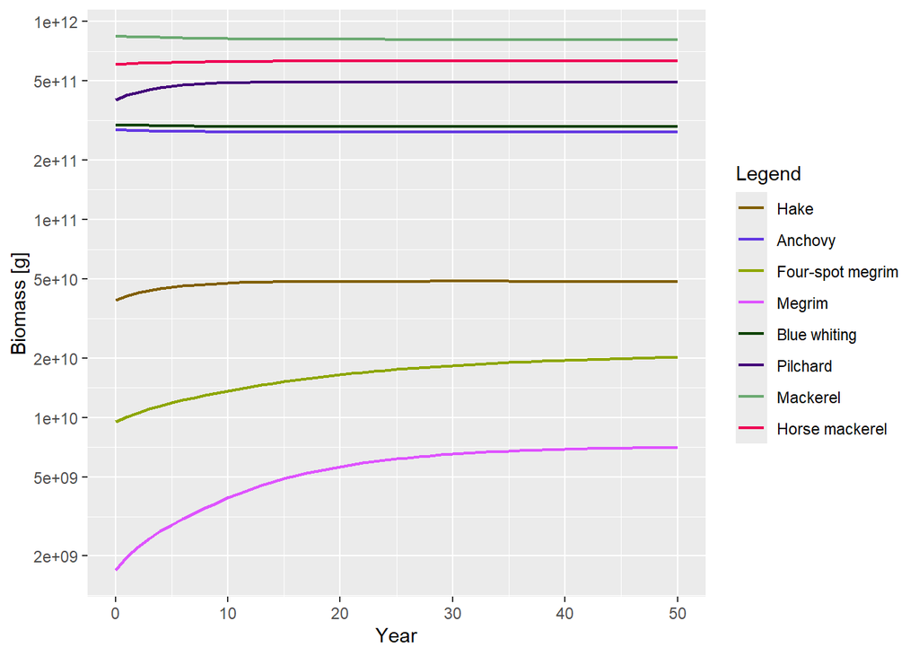

```r
init_eff <- msm@initial_effort; init_eff

sim05 <- project( msm, effort = init_eff * 0.8, t_max = 50)
plotBiomass(sim05)
```

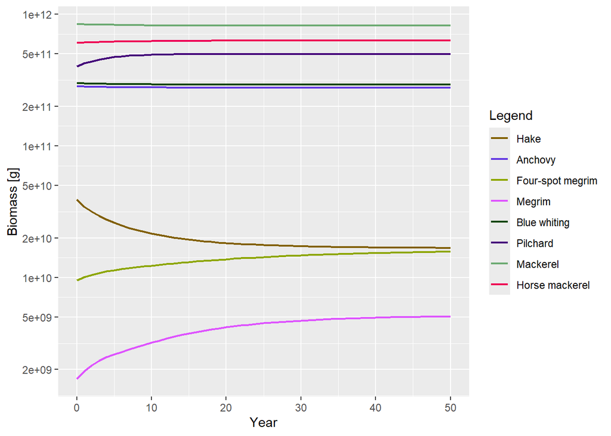

```r
sim15 <- project( msm, effort = init_eff * 1.5, t_max = 50)
plotBiomass(sim15)
```

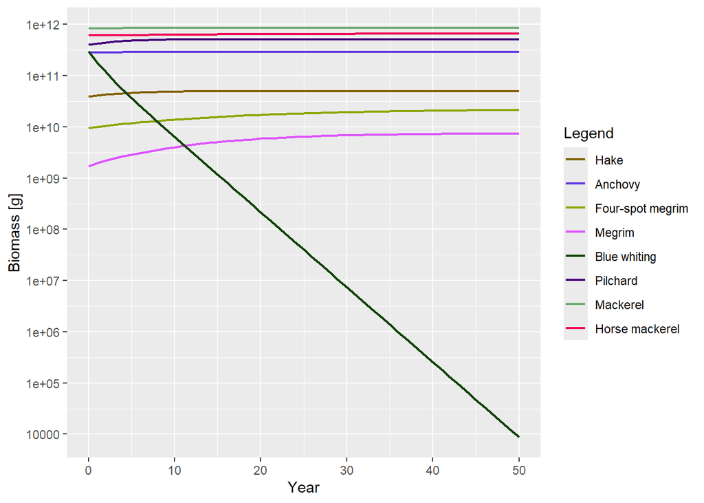

```r
gp <- gear_params(msm)
gp['Blue whiting, Demersales', 'catchability'] <- gp['Blue whiting, Demersales', 'catchability'] * 200
msm2 <- msm
gear_params(msm2) <- gp

sim05 <- project( msm2, effort = init_eff * 0.8, t_max = 50)
plotBiomass(sim05)
```

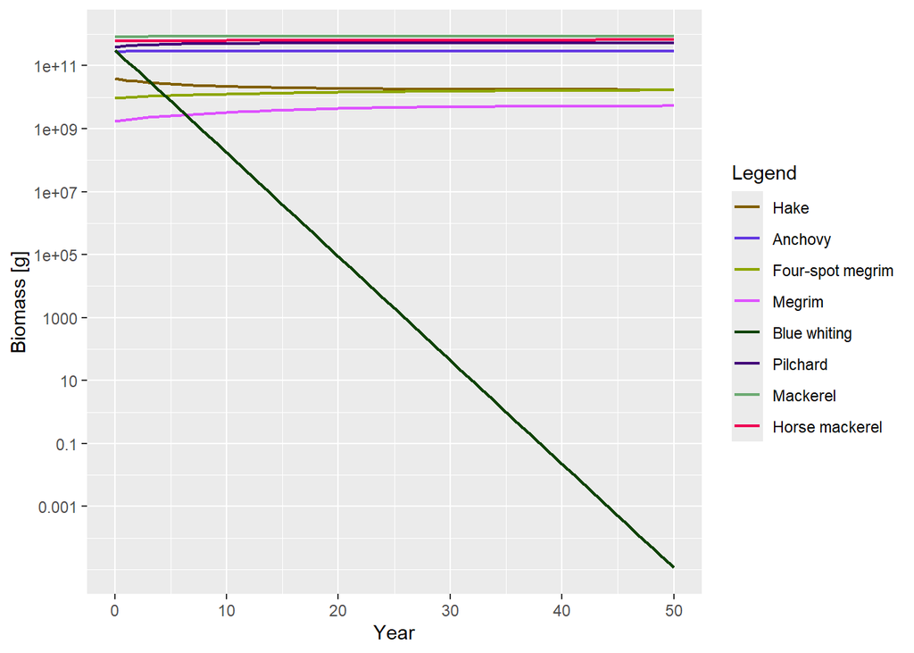

```r
sim15 <- project( msm2, effort = init_eff * 1.5, t_max = 50)
plotBiomass(sim15)
```